# Untitled

Daniel Jach

June 14, 2020

# Einleitung

QuAX-DaF (**Qu**antitative **A**nalyse von Te**X**ten für **D**eutsch **a**ls **F**remdsprache) ist ein online Werkzeug für den DaF-Unterricht, erreichbar unter https://danieljach.shinyapps.io/quax-daf/. Das Programm analysiert deutschsprachige Texte mit Methoden der quantitativen Linguistik und erzeugt Material für Übungen zum Textverstehen und Wortschatzerwerb, angepasst an den Vokabelstand Ihrer Lernenden. QuAX ist für Lehrerinnen und Lehrer gemacht, möglichst praktikabel gestaltet und verlangt kein linguistisches oder statistisches Vorwissen. QuAX ist meines Wissens das erste DaF-Tool, das auf Erkenntnissen der gebrauchsbasierten Spracherwerbsforschung aufbaut und diese für den Unterricht nutzbar macht.

# Gebrauchsbasierter Spracherwerb, Textverstehen und Wortschatz

Ergebnisse psycholinguistischer Forschung haben gezeigt, dass eine Fremdsprache – ähnlich wie eine Muttersprache – zu wesentlichen Teilen aus dem Gebrauch heraus gelernt wird (Ellis, Römer, and O’Donnell 2015; Madlener 2015). Solches erfahrungsbasiertes Lernen ist ein Nebenprodukt mentaler Aktivität und verläuft normalerweise implizit, das heißt ohne dass die Lernenden etwas davon mitbekommen. Gebrauchsbasierte Forschung geht dabei davon aus, dass Lernende einzelne Äußerungen, die ihnen im Sprachgebrauch begegnen, im Gedächtnis behalten und unbewusst hinsichtlich Form und Bedeutung miteinander vergleichen. Wiederkehrende Gemeinsamkeiten schreiben sich tiefer ins Gedächtnis ein, so dass sich sukzessive schematische Abbilder (Repräsentationen) geteilter grammatischer und anderer Eigenschaften herausbilden. Diese gebrauchsbasierten Abbilder unterscheiden sich von ihren Lehrbuch-Beschreibung wie Wildtiere von ihren im Zoo lebenden Artgenossen: Sie sind auf ihre Umgebung feinabgestimmt und in ein enges Netz ähnlicher Konstruktionen eingebunden (Diessel 2019; Römer 2004; Wagner 2015). Die Häufigkeit, mit der eine bestimmte Konstruktion im Input erscheint, ist dabei ein entscheidender Faktor für ihren Erwerb und die Ausgestaltung ihrer Repräsentation (Diessel 2016; Schmid 2018).

Der gebrauchsbasierte Ansatz ist nicht auf den Erwerb grammatischer Konstruktionen beschränkt, sondern bezieht auch den Erwerb von Wörtern ein. Korpuslinguistische Arbeiten haben etwa gezeigt, dass Wörter in Texten nicht wie einzelne Bausteine aneinander gereiht, sondern normalerweise in einem mehr oder weniger engen Verbund mit anderen Wörtern gebraucht werden (Hoey 2004; Sinclair 1991). Erwerb und Verarbeitung solcher Kollokationen hängen wiederum wesentlich von der Häufigkeit ab, mit der Lernende ihnen begegnen (Schmitt 2012). Auch konnotative Anteile der Wortbedeutung werden überwiegend beiläufig aus dem Gebrauch heraus gelernt (Corrigan 2004).

Auf diese Weise erwerben Lernende die Wörter und grammatischen Konstruktionen einer Sprache implizit aus ihren Gebrauchserfahrungen, ähnlich einem neuronalen Netzwerk, das wiederkehrende Muster in seinem Input erkennt, intern abspeichert und die entstehenden Abbilder kontinuierlich nachbessert, ohne dafür eines ``Bewusstseins’’ zu bedürfen oder ein solches zu entwickeln (Elman 1993). Damit werden die Existenz bewusster Lernvorgänge und die Wichtigkeit von Instruktionen keineswegs verneint, sondern ihre Rolle wird im Zusammenspiel mit impliziten Prozessen bestimmbar. Instruktionen haben in diesem Modell vor allem die Funktion, den Lernenden auf noch unbekannte Strukturen in seinem Input aufmerksam zu machen. Bewusste Lernvorgänge steuern ihre Verarbeitung so lange, bis sich ein internes Abbild herausbildet, das diese Aufgabe automatisch und unbewusst übernimmt (Ellis 2015; Roehr-Brackin 2018).

Für den Erwerb realistischer Konstruktionen und ihre idiomatische Feinabstimmung auf den Kontext ist also Erfahrung mit authentischem Sprachgebrauch von besonderer Bedeutung. Im gesteuerten Fremdsprachenerwerb im Herkunftsland ist authentischer Sprachgebrauch vor allem in Form von Texten (und aufgezeichneten Gesprächen) für Lernende erfahrbar. In bildungssprachlichen Domänen, zum Beispiel in der universitären Erwachsenenbildung, in der Vorbereitung auf ein Studium im Ausland oder im deutschsprachigen Fachunterricht an Auslandsschulen, dominieren Texte mit bildungs-, fach- und schriftsprachlichen Registern. Das Verstehen solcher Texte setzt aber normalerweise schon einen relativ großen Wortschatz voraus (Tschirner 2019). Relevant für das Textverstehen sind zum einen besonders häufige Wörter, weil diese mehr als seltene Wörter zur Textdeckung beitragen (Nation 2006). Korpuslinguistische Studien haben jedoch gezeigt, dass die oft für den Unterricht herangezogenen pragmatisch orientierten Wortlisten (zum Beispiel Langenscheidt, Goethe-Institut, Profile Deutsch) nur einen kleinen Teil solcher Wörter enthalten. Genauer gesagt: Statt häufiger Wörter, die wesentlich zum Textverstehen beitragen, enthalten diese Listen überwiegend relativ seltene Wörter, die meist für direkte Gespräche in bestimmten Alltagsdomänen gedacht sind (Tschirner 2006). Auch ein häufigkeitsbasierter DaF-Vokabeltrainer existiert bislang nicht. Zum anderen spielen Wörter bildungs-, fach- und schriftsprachlicher Register eine entscheidende Rolle. Solche Wörter sind in den einschlägigen Wortlisten gewöhnlich nicht enthalten und kommen auch nur selten in alltagssprachlichen Texten vor. Sie sollten im Unterricht daher hervorgehoben und ihr Gebrauch gezielt vermittelt werden.

# QuAX-DaF

## Funktionsweise

QuAX nutzt Methoden und Einsichten der gebrauchsbasierten Spracherwerbsforschung, um deutschsprachige Texte statistisch zu analysieren und für den DaF-Unterricht auf unterschiedlichen Niveaustufen aufzubereiten. Eingegebene Texte werden zunächst lemmatisiert, das heißt flektierte Wortformen werden in ihre Grundform (Lemma) gebracht. Anschließend vergleicht QuAX die Häufigkeit der Wörter im Text mit ihrer Häufigkeit im Deutschen und bildet den Vergleich anschaulich ab. Das ermöglicht es den Lehrenden einzuschätzen, ob der eingegebene Text vor allem gebräuchliche oder ungewöhnlich viele seltene Wörter enthält und welche das sind. Angepasst an den Vokabelstand der Lernenden erzeugt QuAX dann automatisch Übungsmaterial für den typischen unterrichtspraktischen Dreischritt: vor dem Lesen, beim Lesen und nach dem Lesen (Watkins 2017, 20).

## Textanalyse

Wählen Sie für dieses Beispiel den Text *Kinderzeitmaschine: Über Ritter* aus. Der Text ist eine Zusammenstellung mehrerer Beiträge zum Thema *Ritter}, die auf der öffentlich geförderten Webseite* https://www.kinderzeitmaschine.de/* erschienen sind und sich an Kinder im Alter zwischen acht und dreizehn Jahren wenden. Der Text erscheint im Eingabefeld. Klicken Sie anschließend auf die Schaltfläche *Analyse beginnen* und zählen Sie leise bis zehn.

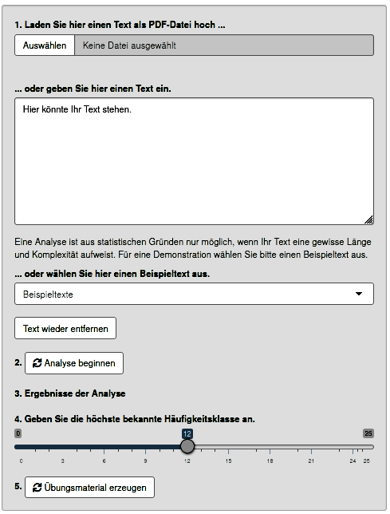

Das Programm ermittelt die Anzahl der einzelnen Wörter in Ihrem Text (Tokens) und vergleicht sie mit der Anzahl verschiedener Wörter (Types). Das Type-Token-Verhältnis ist ein in der Korpuslinguistik häufig genutztes Maß, um die Komplexität eines Textes einzuschätzen. Der Wert steigt mit der Anzahl der Types und fällt mit der Anzahl der Tokens. Der analysierte Text erreicht einen Wert von 0,5. Das bedeutet, dass durchschnittlich jeder Type zweimal im Text als Token vorkommt. Zum Vergleich wird das Type-Token-Verhältnis in den „Sternchen“-Texten der bekannten PASCH-Initiative angezeigt[^1], geordnet nach den Niveaustufen des Gemeinsamen Europäischen Referenzrahmens (GER). Der analysierte Text liegt zwischen den Niveaustufen B2/C1 und C1. Probieren Sie einige andere Beispieltexte aus. Der zweite Beispieltext, das Grimmsche Märchen *Rumpelstilzchen*, zum Beispiel liegt mit einem Type-Token-Verhältnis von 0,4 auf einem Niveau mit den PASCH-Texten der Niveaustufe B1. Die Reportage *Zu Hause im Baumhaus* übersteigt mit einem Wert von 0,57 den Wert der C1-PASCH-Texte. Relativ hohe Werte können auch von der Kürze der analysierten Texte bedingt sein. Ein längerer Auszug aus Siegfried Lenz’ Roman *Deutschstunde* etwa, ein ohne Zweifel für fremdsprachige Leser schwieriger Text, erzielt mit 0,41 einen relativ niedrigen Wert, weil sich Types in längeren Texten häufiger wiederholen.

Anschließend werden Textwörter angezeigt, die QuAX unbekannt sind. Hier erscheinen häufig Eigennamen, technische Ausdrücke, Fremdwörter und seltene Nomen-Komposita. Im *Ritter*-Text sind QuAX zum Beispiel die Wörter *Lehnsherren, Schwertgürtel, Schwertleite, Kampfübungen, Nasalhelm* und *Kettenhaube* unbekannt. Außerdem werden im Gegenwartsdeutsch nicht mehr gebräuchliche Wörter wie *Turnei* und *Tjost* und äußerst seltene Wörter wie die Präteritum-Plural-Form *schützten* angezeigt. Daneben kommt es hin und wieder zu Missverständnissen. Zum Beispiel erkennt QuAX nicht, dass *Das* und *Die* Artikelwörter am Satzanfang bzw. am Beginn einer Überschrift sind. Bei der Analyse von Fachtexten werden hier auch Fachausdrücke aufgelistet. Aus der Definition von *Hermeneutischer Zirkel* etwa sind QuAX unter anderem die Wörter *Zirkelbewegung, Textverstehen, wirkungsgeschichtliches* und *Verstehenskonstituenten* nicht bekannt.

Wie sollten Sie mit diesen Wörtern im Unterricht umgehen? Das hängt auch von Ihren Lernzielen ab. Einige Wörter könnten im Text durch andere Ausdrücke ersetzt werden (z.B. *Kettenhaube* und *Nasalhelm* durch *Schutzhaube* und *Helm*), um die Lektüre zu vereinfachen. Andere Wörter beziehen sich auf sachlich relevante Konzepte, die vor der Lektüre eingeführt werden sollten (z.B. *Lehnsherr*). Wieder andere Wörter sachlich relevanter Konzepte sollten die Lernenden durch die Lektüre selbstständig erschließen (z.B. *Turnei* und *Tjost*, die im Text erklärt werden). Und Fachvokabular (z.B. *Textverstehen* und *Verstehenskonstituenten* aus dem *Hermeneutik*-Textbeispiel) könnten die Lernenden selbstständig während der Lektüre in Fachwörterbüchern nachschlagen.

Das anschließende Diagramm vergleicht den eingegebenen Text mit dem Deutschen. Die Punkte stehen für die Lemmas im Text. Die Lemmas erscheinen, wenn Sie mit der Maus über die Punkte fahren. Ihre Häufigkeit im Text ist auf der horizontalen Achse abgetragen, ihre Häufigkeit im Deutschen auf der vertikalen Achse. Das Wort *Ritter* zum Beispiel ist im analysierten Text häufig, im Deutschen dagegen eher selten, und erscheint dementsprechend in der rechten unteren Ecke des Diagramms. Angezeigt wird nicht die absolute Häufigkeit, sondern (grob gesagt) wie häufig oder selten ein Wort im Text bzw. im Deutschen verglichen mit einem durchschnittlich häufigen Wort vorkommt. Sogenannte Stoppwörter, die für den Textinhalt eine untergeordnete Rolle spielen, zum Beispiel *aber, am, denn, diesen, keine, manche, sonst, unser* und *zwischen*, wurden aussortiert, weil sie besonders häufig auftreten und das Diagramm darum stark verzerren würden. Sie können das Diagramm bewegen und heranzoomen (Werkzeugleiste).

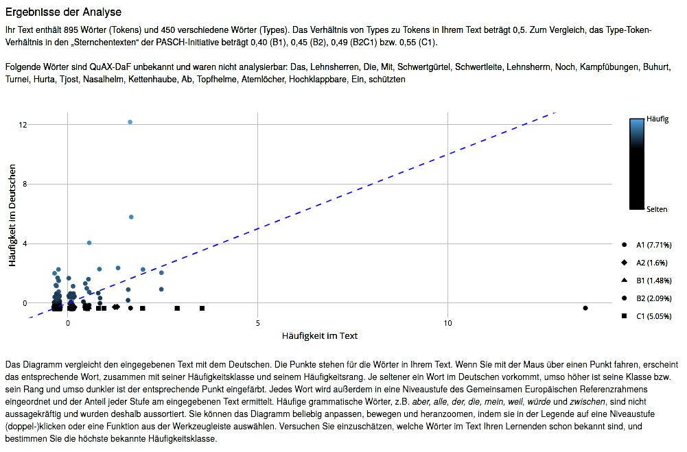

Wörter, die im Deutschen häufig, aber im Text relativ selten vorkommen, erscheinen oberhalb der blauen Linie. Hierzu gehören im Beispieltext etwa *geben, sollen, kommen, neu, sagen, Jahr* und die Verschmelzungen von *in* und *zu* mit Artikelwörtern zu den Formen *im* und *zum*. Diese Wörter verursachen vermutlich keine besonderen Verstehensschwierigkeiten. Sofern sie Ihren Lernenden aber noch nicht bekannt sind, sollten diese Wörter vorrangig gelernt werden. Sie sind zwar im untersuchten Text relativ selten, kommen aber in anderen Texten umso häufiger vor und tragen dort wesentlich zur Textdeckung bei.

Wörter, die im Deutschen selten, aber im Text relativ häufig vorkommen, erscheinen unterhalb der blauen Linie. Sie verdienen besondere Aufmerksamkeit. Sie tragen zur Textdeckung bei und spielen inhaltlich vermutlich eine wichtige Rolle in Ihrem Text. Dazu gehören im *Ritter*-Text die Wörter *Ritter, Schwert, Lanze, Knappe, Schild* und *Jahrhundert*. Eine Analyse von Grimms Märchen *Rumpelstilzchen* platziert an dieser Position bezeichnenderweise die Wörter *Männchen, Stroh, Gold* und *spinnen*. Die häufige direkte Rede im Märchentext zeigt sich in der überproportionalen Verwendung von *sprechen* (z.B. *Der König sprach zum Müller: …*). Ein Auszug aus Anne Franks Tagebuch enthält besonders häufig die Wörter *Vater, Mutter* und den Namen von Annes Schwester, *Margot*, aber auch *Haus*, *kommen* und *gehen* kommen relativ häufig vor. Bei der Analyse von Fachtexten wie der Definition von *Hermeneutischer Zirkel* erscheint hier unter anderem fachspezifische Terminologie, die im normalen Sprachgebrauch nur selten verwendet wird, zum Beispiel *Text, Zirkel, Interpretation* und *Spirale*. Diese Wörter sind im Deutschen selten, erscheinen im untersuchten Text aber überproportional häufig und scheinen besonders prägend für den untersuchten Text zu sein.

Am Achsenschnittpunkt sammeln sich Wörter, die sowohl im Deutschen als auch im Text relativ selten sind, in einer dichten Wolke. Hierzu gehören im *Ritter*-Text zum Beispiel *kämpfen, lernen, Gesicht, allein, Holz, Gedicht, Krieg, dreieckig, zusammenbauen* und *ernennen*. Je größer und dichter diese Wolke ist, umso mehr verschiedene Wörter enthält der Text, einen umso größeren Wortschatz verlangt er von den Lernenden und umso schwieriger ist er dementsprechend zu verstehen.

[output not shown]

Corrigan, Roberta. 2004. “The Acquisition of Word Connotations: Asking ‘What Happened’.” *Journal of Child Language* 31 (2). Cambridge University Press: 381–98. doi:10.1017/S0305000903005981.

Diessel, Holger. 2016. “Frequency and Lexical Specificity in Grammar: A Critical Review.” In *Experience Counts: Frequency Effects in Language*, edited by Heike Behrens and Stefan Pfänder, 209–38. Berlin, Germany: De Gruyter.

———. 2019. *The Grammar Network: How Linguistic Structure Is Shaped by Language Use*. Cambridge, England: Cambridge University Press.

Ellis, Nick C. 2015. “Implicit AND Explicit Language Learning: Their Dynamic Interface and Complexity.” In *Implicit and Explicit Learning of Languague*, edited by Patrick Rebuschat. 3–23. Amsterdam, The Netherlands: John Benjamins.

Ellis, Nick C., Ute Römer, and Matthew O’Donnell. 2015. “Second Language Constructions: Usage-Based Acquisition and Transfer.” In *The Cambridge Handbook of Bilingual Processing*, edited by John W. Schwieter, 234–54. Cambridge, England: Cambridge University Press.

Elman, Jeffrey L. 1993. “Learning and Development in Neural Networks: The Importance of Starting Small.” *Cognition* 48 (1): 71–99. doi:10.1016/0010-0277(93)90058-4.

Hoey, Michael. 2004. “The Textual Priming of Lexis.” In *Corpora and Language Learners*, edited by Guy Aston, Silvia Bernardini, and Dominic Stewart, 21–41. Amsterdam, The Netherlands: John Benjamins.

Madlener, Karin. 2015. *Frequency Effects in Instructed Second Language Acquisition*. De Gruyter.

Nation, I. S. Paul. 2006. “How Large a Vocabulary Is Needed for Reading and Listening?” *Canadian Modern Language Review* 63: 59–82.

Roehr-Brackin, K. 2018. *Metalinguistic Awareness and Second Language Acquisition*. New York, NY: Routledge.

Römer, Ute. 2004. “Comparing Real and Ideal Language Learner Input: The Use of an EFL Textbook Corpus in Corpus Linguistics and Language Teaching.” In *Corpora and Language Learners*, edited by Guy Aston, Silvia Bernardini, and Dominic Stewart, 151–68. Amsterdam, The Netherlands: John Benjamins.

Schmid, Hans-Jörg. 2018. “Unifying Entrenched Tokens and Schematized Types as Routinized Commonalities of Linguistic Experience.” In *Yearbook of the German Cognitive Linguistics Association*, 6:167–82. 1. doi:10.1515/gcla-2018-0008.

Schmitt, Norbert. 2012. “Formulaic Language and Collocation.” In *The Encyclopedia of Applied Linguistics*, edited by Carol A. Chapelle, 1–10. Malden, MA: Wiley-Blackwell. doi:10.1002/9781405198431.wbeal0433.

Sinclair, John. 1991. *Corpus, Concordance, Collocation*. Oxford, England: Oxford University Press.

Tschirner, Erwin. 2006. “Häufigkeitsverteilungen Im Deutschen Und Ihr Einfluss Auf Den Erwerb Des Deutschen Als Fremdsprache.” In *Atti Del Xii Congresso Internationale Di Lessicografia*, edited by Elisa Corina, Carla Marello, and Christina Onesti, 1277–88. Alessandria, Italy: Edizioni dell’Orso.

———. 2019. “Der Rezeptive Wortschatzbedarf Im Deutschen Als Fremdsprache.” In *Akten Der XVI. Internationalen Deutschlehrertagung (IDT)*, edited by T. Studer, I. Thonhauser, and E. Peyer, 98–111. Erich Schmidt.

Wagner, Johannes. 2015. “Designing for Language Learning in the Wild: Creating Social Infrastructures for Second Language Learning.” In *Usage-Based Perspectives on Second Language Learning*, edited by Soren W. Eskildsen and Teresa Cadierno, 75–101. De Gruyter.

Watkins, Peter. 2017. *Teaching and Developing Reading Skills*. Cambridge, England: Cambridge University Press.

[^1]: https://www.pasch-net.de/de/pas/cls/leh/unt/dst.html, heruntergeladen am 2. Januar 2020.